# Gráficas con `ggplot2`

Parte 2: Graficación avanzada en `R`

Autores

Rodrigo Zepeda-Tello y Rossana Torres

Última actualización

October 5, 2022

Resumen

**Warning**

Si aún no cuentas con una instalación de `ggplot2` dentro de `R` ve a la [sección de instalación de paquetes](https://rodrigozepeda.github.io/CursoR/Introducci%C3%B3n_a_R.html#instalaci%C3%B3n-de-paquetes) o bien corre la siguiente instrucción:

```r
install.packages("ggplot2")
```

## 1 Histogramas con `ggplot2`

### 1.1 Un histograma es una gráfica de barras especial

El comando `geom_histogram` sirve para crear histogramas. Un histograma es un tipo de gráfico de barras que acumula en cada barra conteos de cuántos cayeron en ese sitio. Para entender mejor, veamos un ejemplo. Para ello copia el siguiente código el cual genera una base de datos expuesta a continuación:

```r
datos_histograma <- tibble(
  estaturas = c(1.42, 1.45, 1.65, 1.55, 1.32, 1.44, 1.50, 1.51, 1.62, 1.55)
)
```

| estaturas |
| --- |
| 1.42 |
| 1.45 |
| 1.65 |
| 1.55 |
| 1.32 |
| 1.44 |
| 1.50 |
| 1.51 |
| 1.62 |
| 1.55 |

Viendo la base de datos notamos que puede resumirse según fueron cayendo en distintos intervalos:

| Intervalo | n |
| --- | --- |
| 1.3 - 1.4 | 1 |
| 1.4 - 1.5 | 4 |
| 1.5 - 1.6 | 3 |
| 1.6 - 1.7 | 2 |

Podemos elaborar fácilmente una gráfica de barras para ese conteo:

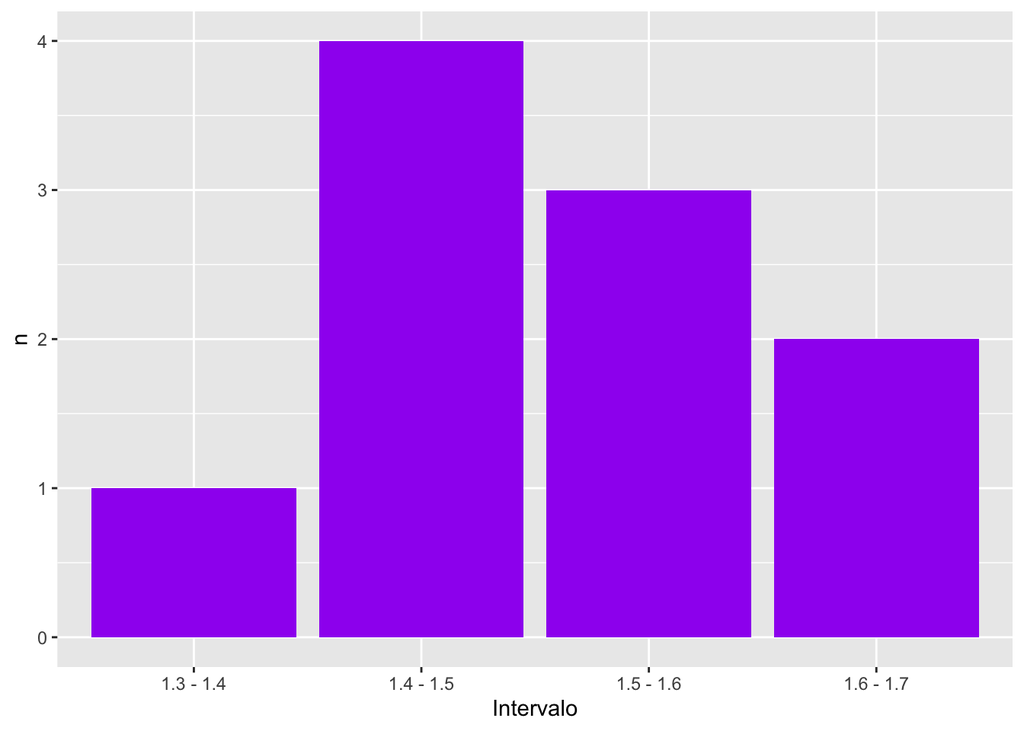

donde, de nuevo, la altura de la barra corresponde al conteo de cuántos cayeron en ese intervalo.

Podemos también hacer una gráfica de barras donde no pongamos el conteo absoluto sino el porcentaje (sabemos que hay 10 mediciones en total) y esto se vería así:

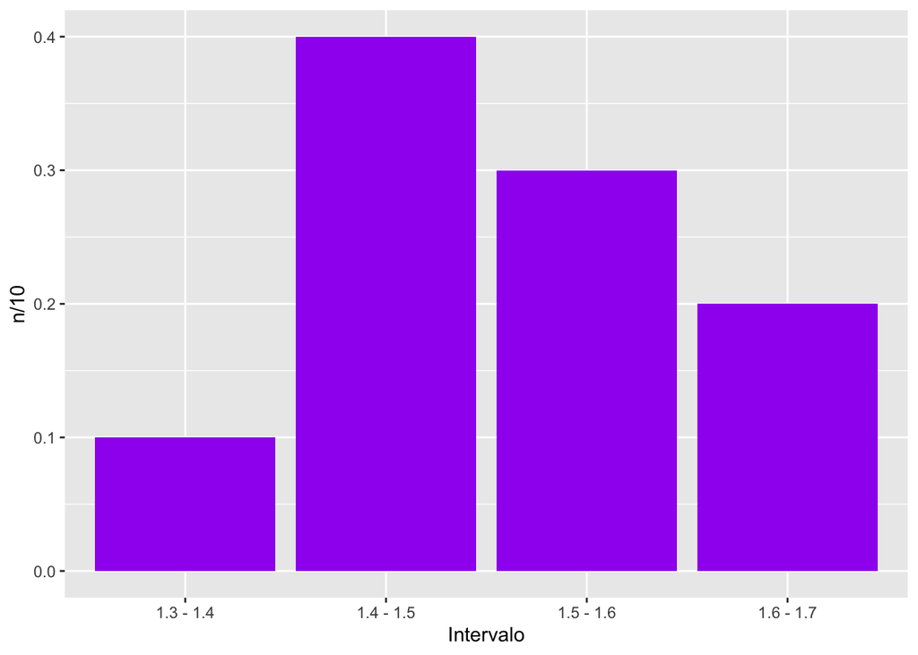

Un histograma representa la misma idea que estas gráficas de barras de manera simplificada. Usando los datos asignados previamente puedo construir un histograma como sigue:

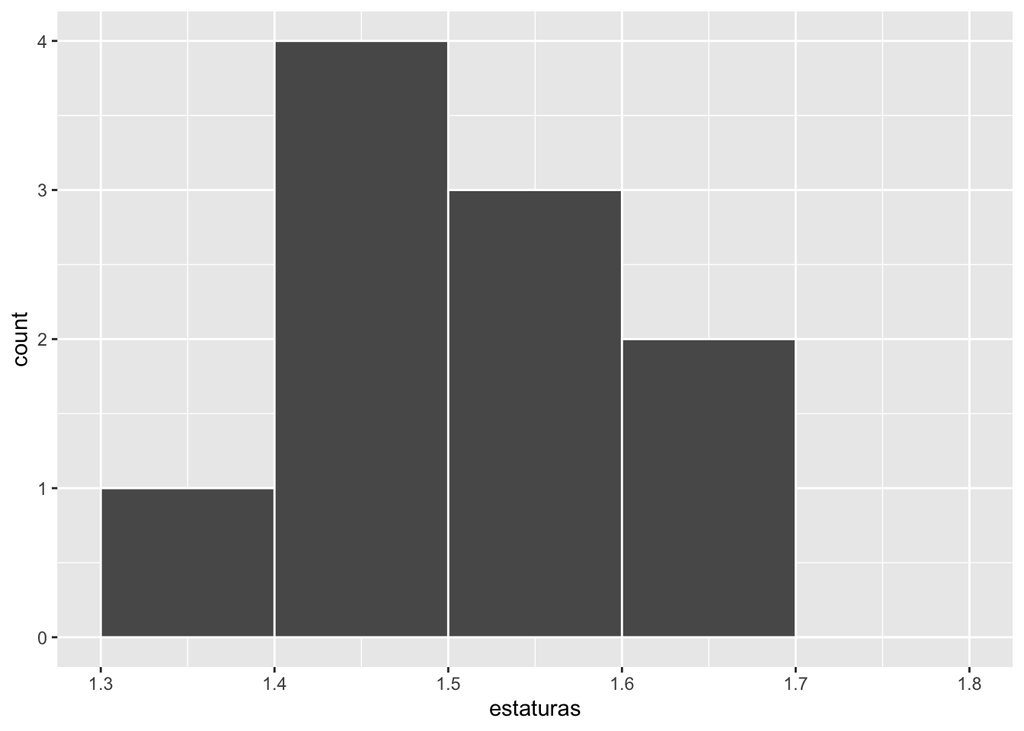

```r
ggplot(datos_histograma) +
  geom_histogram(aes(x = estaturas), color = "white",
                 breaks = c(1.3, 1.4, 1.5, 1.6, 1.7, 1.8))
```

donde los `breaks` indican a `R` dónde hacer los cortes (volveremos más adelante).

Si quisiéramos verlo como porcentaje y no cómo conteo basta con agregar una opción (muy específica que a nadie se le va a ocurrir sin googlearlo) de `y = (..count..)/sum(..count..)` en el `aes` como sigue:

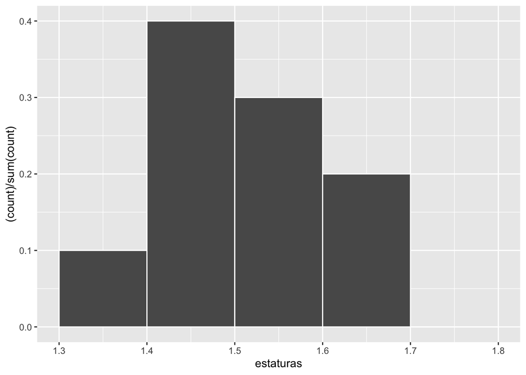

```r
ggplot(datos_histograma) +
  geom_histogram(aes(x = estaturas, y = (..count..)/sum(..count..)),
                 color = "white",
                 breaks = c(1.3, 1.4, 1.5, 1.6, 1.7, 1.8))
```

¡Hagamos entonces nuestro primer histograma!

### 1.2 Histograma de colesterol

Tomaremos de nuevo la base de diabetes que usamos en la sección anterior. Para ello la leemos:

```r
datos_diabetes <- read_csv("datasets/diabetes.csv")
```

Para armar el histograma es sólo necesario especificar una variable en el `aes`:

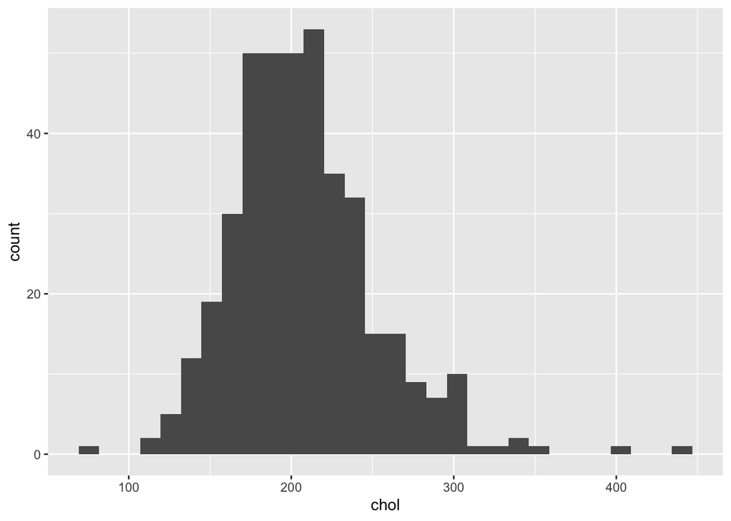

```r
#Graficación de un histograma
ggplot(datos_diabetes) +
  geom_histogram(aes(x = chol))
```

Date cuenta que solito `R` decide cuántas barras poner.

::: callout-note Según [Ioannidis](http://www.madgik.di.uoa.gr/sites/default/files/vldb03_pp19-30.pdf) histograma viene del griego *histos* (mástil) y *gram-ma* (algo escrito). Por lo que literalmente sería algo escrito en mástiles. A pesar de que éstos se atribuyen a Karl Pearson, los histogramas fueron inventados desde antes. Él fue quien les puso nombre. :::

Para especificar el número de barras hay dos formas: utilizando el comando `bins` lo que le dice a `R` cuántas barras poner:

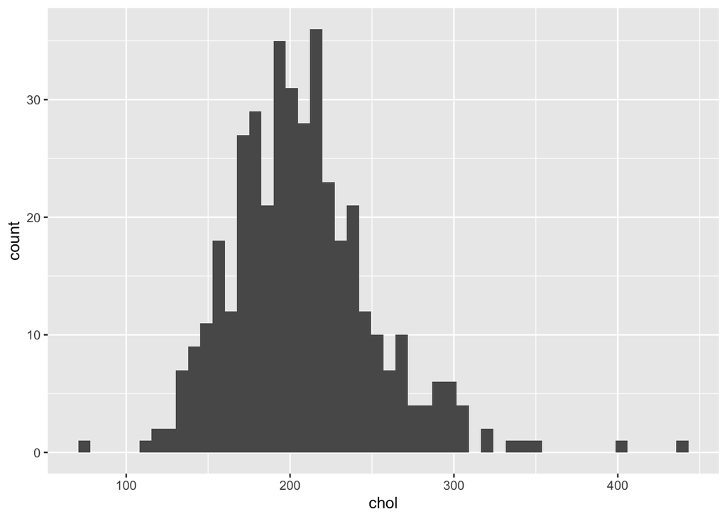

```r
#Graficación de un histograma con 50 barras
ggplot(datos_diabetes) +
  geom_histogram(aes(x = chol), bins = 50)
```

O bien especificando el ancho de cada barra y dejando a `R` decidir:

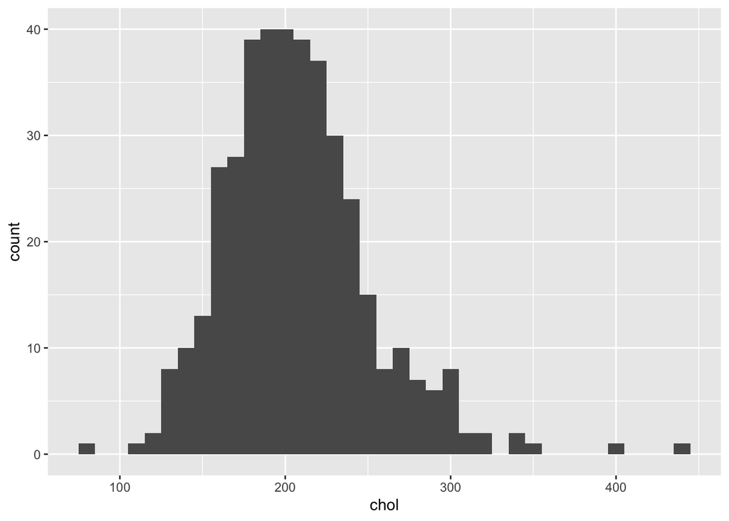

```r
#Graficación con barras de ancho 10
ggplot(datos_diabetes) +
  geom_histogram(aes(x = chol), binwidth = 10)
```

o bien especificando de dónde a dónde van los puntos de corte de cada barra:

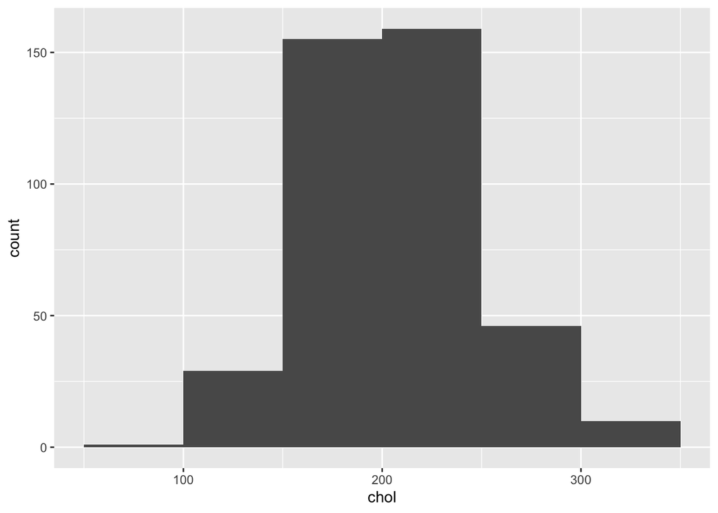

```r
#Graficación con barras de ancho 10
ggplot(datos_diabetes) +
  geom_histogram(aes(x = chol),
                 breaks = c(50, 100, 150, 200, 250, 300, 350))
```

El comando `fill` cambia el color interno de las barras.

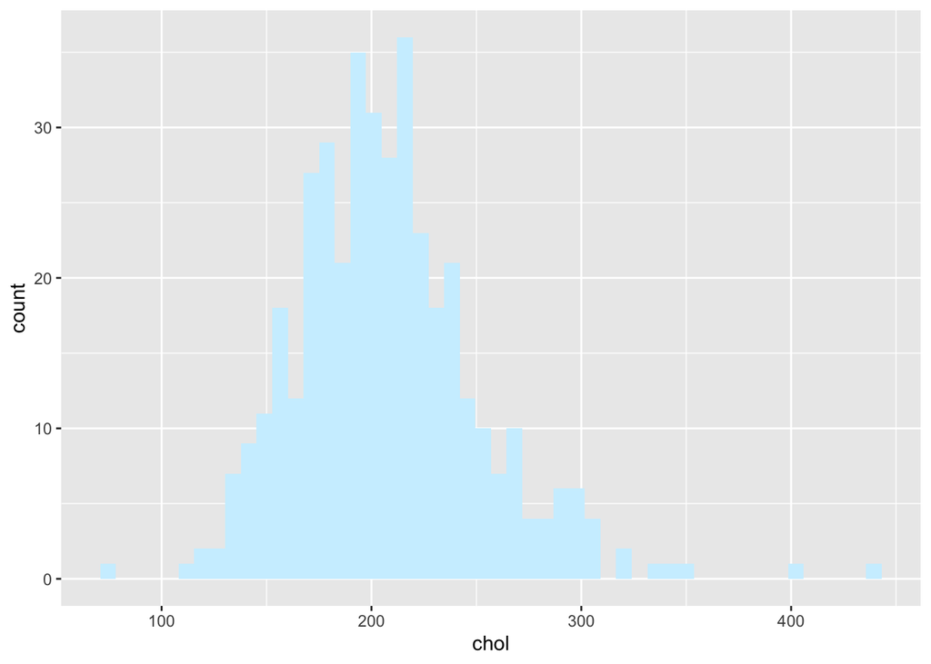

```r
#El comando fill cambia el color
ggplot(datos_diabetes) +
  geom_histogram(aes(x = chol), bins = 50, fill = "#cef0ff")
```

Mientras que el comando `color` cambia el color del borde de la misma:

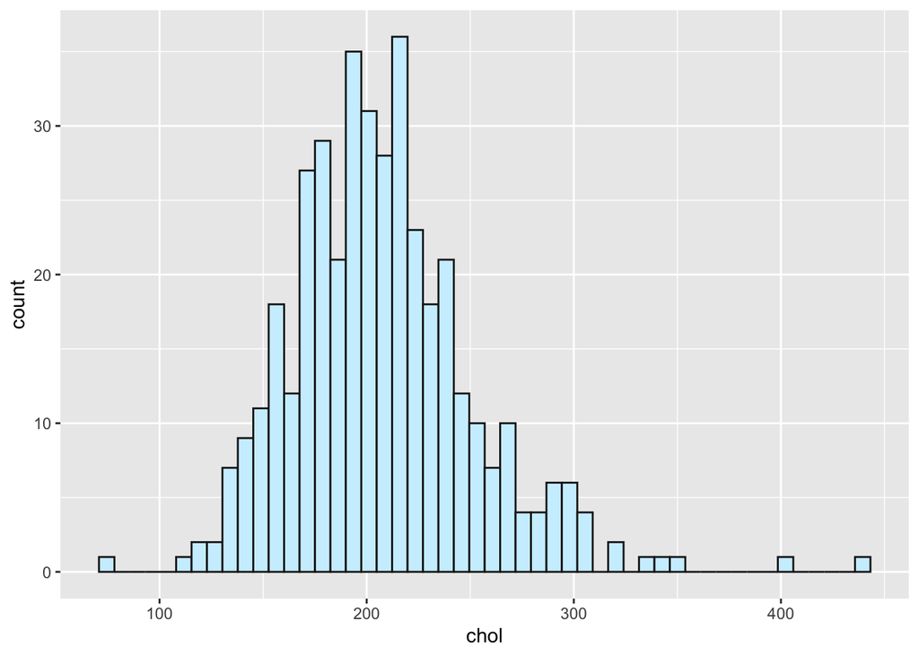

```r
ggplot(datos_diabetes) +
  geom_histogram(aes(x = chol), bins = 50,
                 fill = "#cef0ff",  color = "#1D1B1B")
```

FInalmente, podemos hacer que el histograma muestre no el número de casos totales en la base sino la proporción de los casos mediante `y = ..density..`. La diferencia entre `..density..` y `(..count..)/sum(..count..)` es que ``..density..` está hecho para que la suma de las áreas de los rectángulos dé $1$ mientras que en `(..count..)/sum(..count..)` la suma de las alturas de los rectángulos es la que da $1$.

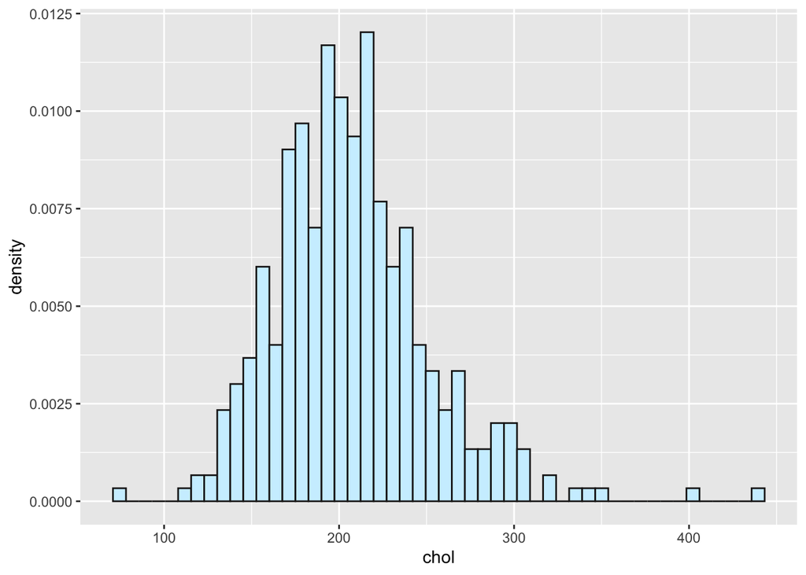

```r
#..density.. nos da el % de casos de manera normalizada
#para que los rectángulos sumen sus áreas a área 1
ggplot(datos_diabetes) +
  geom_histogram(aes(x = chol, y = ..density..),
                 bins = 50, fill = "#cef0ff",  color = "#1D1B1B")
```

Podemos agregar, además, una densidad kernel que nos dé una idea de cómo se ve la distribución ajustada. Como veremos más adelante, la densidad kernel (aunque puede ser manipulable) es más fácil que no nos dé errores de distribución incorrecta.

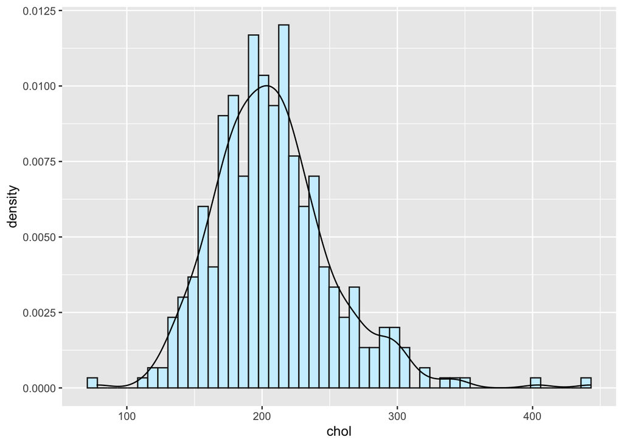

```r
#Gráfica de histograma con densidad kernel
ggplot(datos_diabetes) +
  geom_histogram(aes(x = chol, y = ..density..),
                 bins = 50,
                 fill = "#cef0ff",  color = "#1D1B1B") +
  geom_density(aes(x = chol))
```

**Ojo** `ggplot2` funciona por capas por lo cual el orden en el que se agrega cada capa (`geom`) sí afecta el cómo se ve. Si ponemos el `geom_density` antes del `geom_histogram` nos queda la línea *detrás* del histograma:

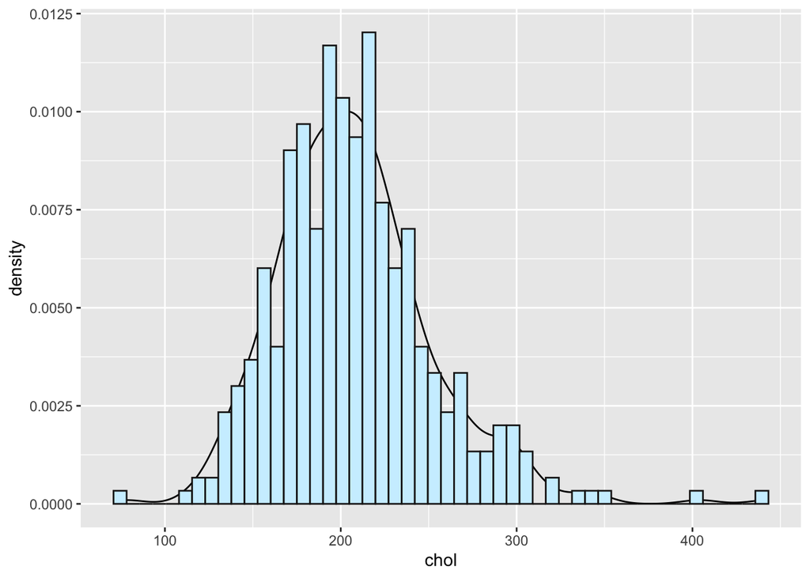

```r
#Gráfica de histograma con densidad kernel
ggplot(datos_diabetes) +
  geom_density(aes(x = chol)) +
  geom_histogram(aes(x = chol, y = ..density..),
                 bins = 50,
                 fill = "#cef0ff",  color = "#1D1B1B")
```

Continuando con la edición podemos cambiar los parámetros de `color` y `size` de la distribución para ajustar su color y tamaño. Así mismo, [`linetype` nos da una línea discontinua](https://ggplot2.tidyverse.org/reference/aes_linetype_size_shape.html):

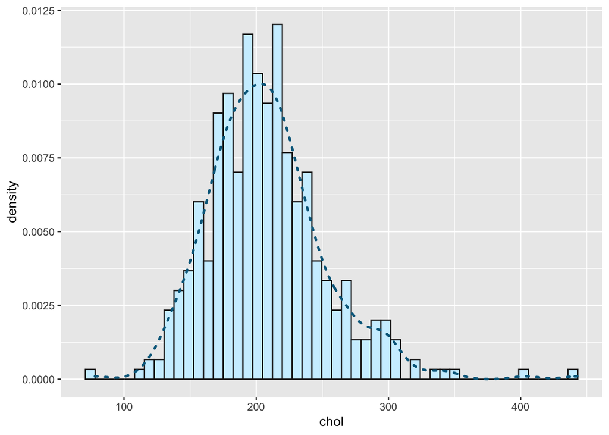

```r
#Cambio de color y tipo de línea a la densidad
ggplot(datos_diabetes) +
  geom_histogram(aes(x = chol, y = ..density..),
                 bins = 50,
                 fill = "#cef0ff",  color = "#1D1B1B") +
  geom_density(aes(x = chol), color = "deepskyblue4",
               linetype = "dotted", size = 1)
```

Finalmente, modificamos los temas:

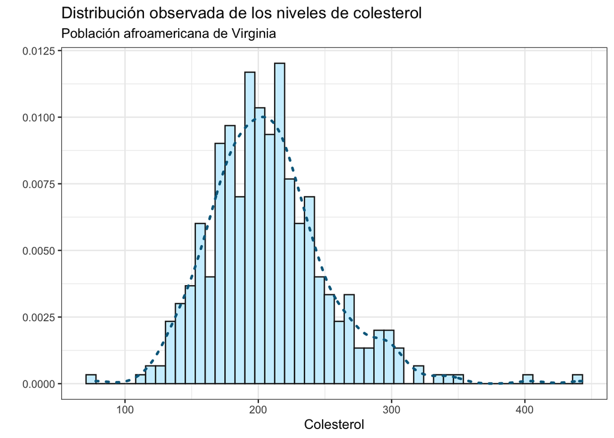

```r
#Graficación con barras de ancho 0.05
ggplot(datos_diabetes) +
  geom_histogram(aes(x = chol, y = ..density..),
                 bins = 50,
                 fill = "#cef0ff",  color = "#1D1B1B") +
  geom_density(aes(x = chol), color = "deepskyblue4",
               linetype = "dotted", size = 1) +
  labs(
    x        = "Colesterol",
    y        = "",
    title    = "Distribución observada de los niveles de colesterol",
    subtitle = "Población afroamericana de Virginia"
  ) +
  theme_bw()
```

La función `mean` calcula la media de una columna dentro de una base de datos. Podemos calcular la media de la columna de `chol` dentro de `datos_diabetes`:

```r
#Media de la columna de colesterol
#la opción na.rm = T es para no considerar los valores missing

promedio_colesterol <- mean(datos_diabetes$chol) #No funciona pues tiene un missing
promedio_colesterol
```

```
[1] NA
```

```r
#Acá le decimos que ignore el missing con na.rm = T
promedio_colesterol <- mean(datos_diabetes$chol, na.rm = T)
promedio_colesterol
```

```
[1] 207.8458
```

Y agregamos una línea vertical a la gráfica exactamente en la media:

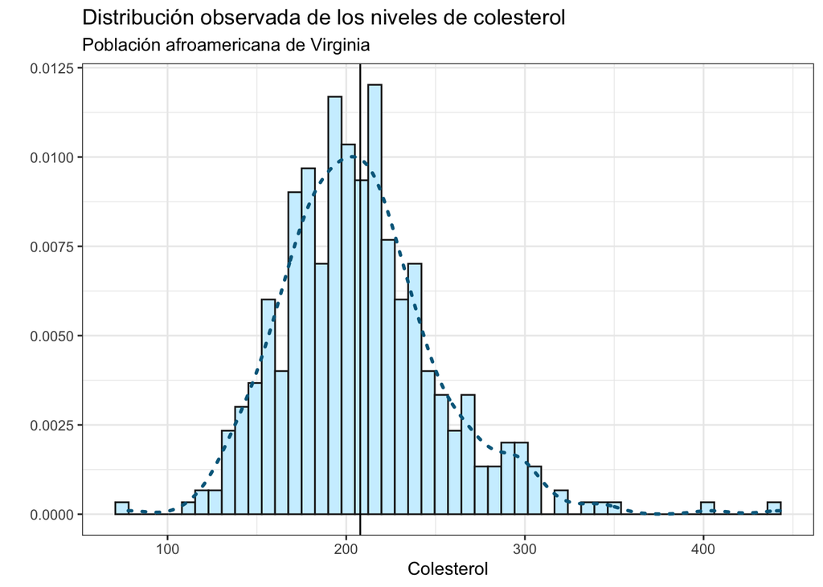

```r
#Agregamos indicadora del promedio
ggplot(datos_diabetes) +
  geom_histogram(aes(x = chol, y = ..density..), bins = 50,
                 fill = "#cef0ff",  color = "#1D1B1B") +
  geom_density(aes(x = chol), color = "deepskyblue4",
               linetype = "dotted", size = 1) +
  labs(
    x        = "Colesterol",
    y        = "",
    title    = "Distribución observada de los niveles de colesterol",
    subtitle = "Población afroamericana de Virginia"
  ) +
  theme_bw() +
  geom_vline(aes(xintercept = promedio_colesterol))
```

Podemos cambiar el color de la línea así como el tipo:

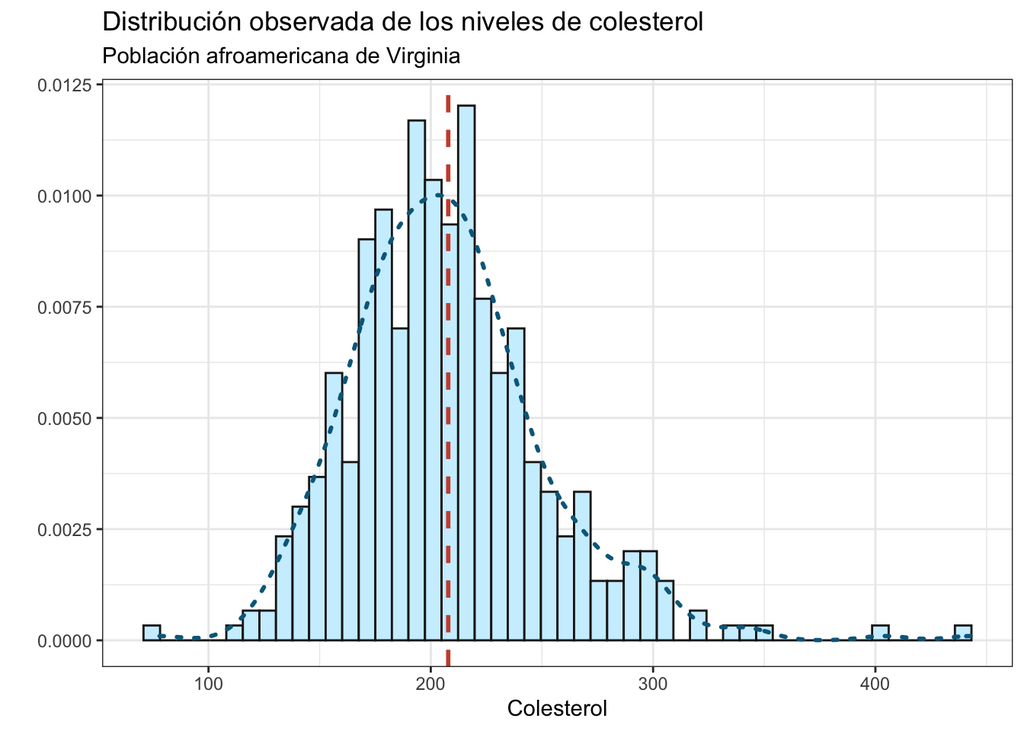

```r
#Agregamos indicadora del promedio
ggplot(datos_diabetes) +
  geom_histogram(aes(x = chol, y = ..density..), bins = 50,
                 fill = "#cef0ff",  color = "#1D1B1B") +
  geom_density(aes(x = chol), color = "deepskyblue4",
               linetype = "dotted", size = 1) +
  labs(
    x        = "Colesterol",
    y        = "",
    title    = "Distribución observada de los niveles de colesterol",
    subtitle = "Población afroamericana de Virginia"
  ) +
  theme_bw() +
  geom_vline(aes(xintercept = promedio_colesterol),
             color = "tomato3", linetype = "dashed", size = 1)
```

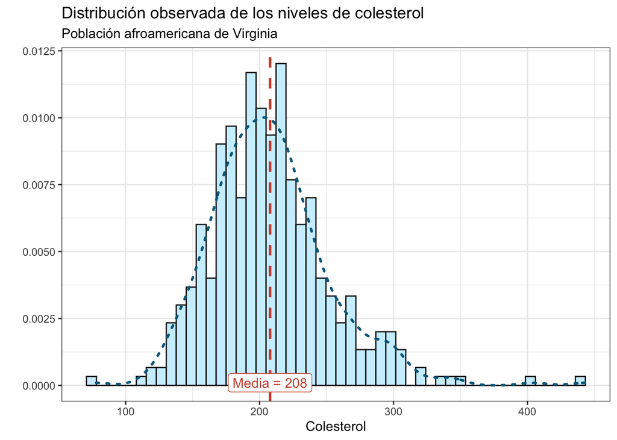

```r
#Agregamos indicadora del promedio
ggplot(datos_diabetes) +
  geom_histogram(aes(x = chol, y = ..density..), bins = 50,
                 fill = "#cef0ff",  color = "#1D1B1B") +
  geom_density(aes(x = chol), color = "deepskyblue4",
               linetype = "dotted", size = 1) +
  labs(
    x        = "Colesterol",
    y        = "",
    title    = "Distribución observada de los niveles de colesterol",
    subtitle = "Población afroamericana de Virginia"
  ) +
  theme_bw() +
  geom_vline(aes(xintercept = promedio_colesterol),
             color = "tomato3", linetype = "dashed", size = 1) +
  annotate("label", x = promedio_colesterol,
           y = 0.0001, label = "Media = 208", color = "tomato3")
```

La función de `scale_y_continuous` permite agregar etiquetas al eje vertical (`scale_x_continuous` si fuera el horizontal). En este caso podemos usar porcentajes para mejor representar los datos:

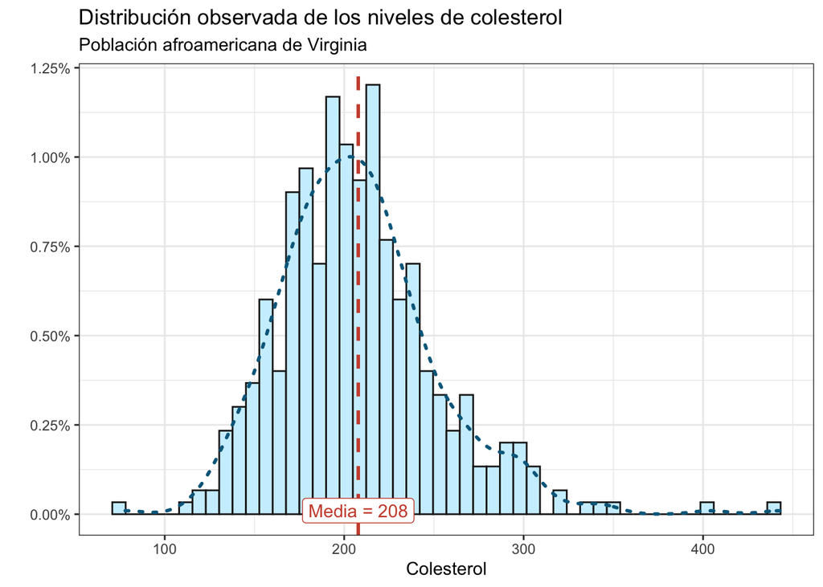

```r
#Agregamos indicadora del promedio
ggplot(datos_diabetes) +
  geom_histogram(aes(x = chol, y = ..density..), bins = 50,
                 fill = "#cef0ff",  color = "#1D1B1B") +
  geom_density(aes(x = chol), color = "deepskyblue4",
               linetype = "dotted", size = 1) +
  labs(
    x        = "Colesterol",
    y        = "",
    title    = "Distribución observada de los niveles de colesterol",
    subtitle = "Población afroamericana de Virginia"
  ) +
  theme_bw() +
  geom_vline(aes(xintercept = promedio_colesterol),
             color = "tomato3", linetype = "dashed", size = 1) +
  annotate("label", x = promedio_colesterol,
           y = 0.0001, label = "Media = 208",  color = "tomato3") +
  scale_y_continuous(labels = scales::percent)
```

### 1.3 Ejercicios

1. Utiliza la función `quantile` (con la opción `na.rm = T`) para calcular los cuantiles `0.975` y `0.025` y agrega dos líneas verticales a la gráfica anterior indicando los valores de los cuantiles junto con sus etiquetas:

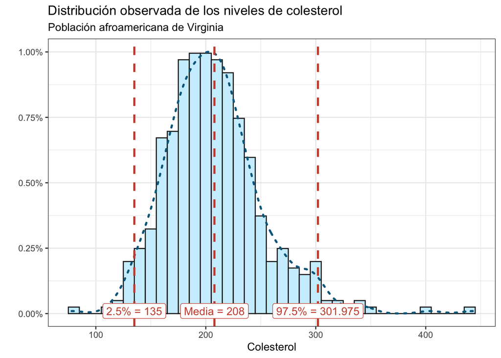

2. Imita la siguiente gráfica de altura en pulgadas (`height`) con color `red` donde se usó el comando `fill` para colorear el interior de la densidad en azul (`deepskyblue4`) y el tema `theme_linedraw`.

> **Nota** quizá necesites modificar la transparencia con `alpha`.

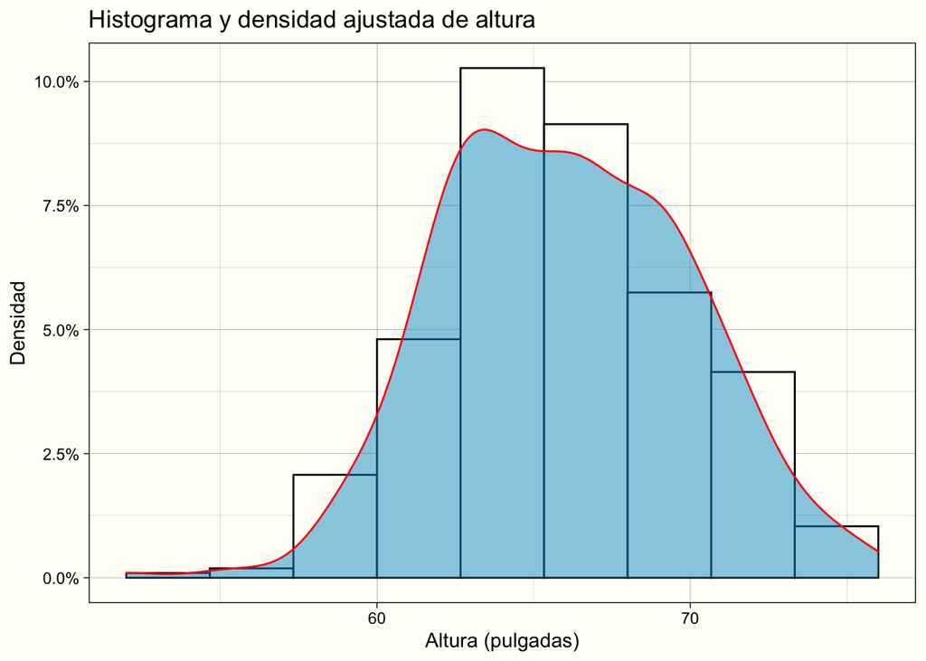

3. Considera la siguiente base de datos:

```r
mis.datos <- data.frame(
  x = c(1.03, 1.24, 1.47, 1.52, 1.92, 1.93, 1.94, 1.95, 1.96, 1.97,
       1.98, 1.99, 2.72, 2.75, 2.78, 2.81, 2.84, 2.87, 2.90, 2.93,
       2.96, 2.99, 3.60, 3.64, 3.66, 3.72, 3.77, 3.88, 3.91, 4.14,
       4.54, 4.77, 4.81, 5.62)
)
```

Realiza un histograma de la variable `x` dentro de `mis.datos` con `binwidth` a `0.75`:

1. ¿Podemos concluir la forma de la distribución a partir del histograma? Es decir ¿está centrada?

**Tip**

Minitab tiene un [blog](https://blog.minitab.com/blog/3-things-a-histogram-can-tell-you) sobre cuándo usar histogramas. ¿Puedes descubrir todos sus errores?

2. Realiza el mismo histograma pero ahora con un ancho de banda de `1.2`. ¿Y ahora?
4. Considera la siguiente [base de datos](https://stats.stackexchange.com/questions/51718/assessing-approximate-distribution-of-data-based-on-a-histogram):

```r
mis.datos <- data.frame(
  A =  c(3.15, 5.46, 3.28, 4.20, 1.98, 2.28, 3.12, 4.10, 3.42, 3.91,
         2.06, 5.53, 5.19, 2.39, 1.88, 3.43, 5.51, 2.54, 3.64, 4.33,
         4.85, 5.56, 1.89, 4.84, 5.74, 3.22, 5.52, 1.84, 4.31, 2.01,
         4.01, 5.31, 2.56, 5.11, 2.58, 4.43, 4.96, 1.90, 5.60, 1.92),
  B =  c(2.90, 5.21, 3.03, 3.95, 1.73, 2.03, 2.87, 3.85, 3.17, 3.66,
         1.81, 5.28, 4.94, 2.14, 1.63, 3.18, 5.26, 2.29, 3.39, 4.08,
         4.60, 5.31, 1.64, 4.59, 5.49, 2.97, 5.27, 1.59, 4.06, 1.76,
         3.76, 5.06, 2.31, 4.86, 2.33, 4.18, 4.71, 1.65, 5.35, 1.67),
  C =  c(2.65, 4.96, 2.78, 3.70, 1.48, 1.78, 2.62, 3.60, 2.92, 3.41,
         1.56, 5.03, 4.69, 1.89, 1.38, 2.93, 5.01, 2.04, 3.14, 3.83,
         4.35, 5.06, 1.39, 4.34, 5.24, 2.72, 5.02, 1.34, 3.81, 1.51,
         3.51, 4.81, 2.06, 4.61, 2.08, 3.93, 4.46, 1.4, 5.1, 1.42),
  D =  c(2.40, 4.71, 2.53, 3.45, 1.23, 1.53, 2.37, 3.35, 2.67, 3.16,
         1.31, 4.78, 4.44, 1.64, 1.13, 2.68, 4.76, 1.79, 2.89, 3.58,
         4.10, 4.81, 1.14, 4.09, 4.99, 2.47, 4.77, 1.09, 3.56, 1.26,
         3.26, 4.56, 1.81, 4.36, 1.83, 3.68, 4.21, 1.15, 4.85, 1.17)
)
```

Grafica un histograma de las variables `A`, `B`, `C` y `D` de dicha base con un ancho de banda (`binwidth`) igual a `1`:

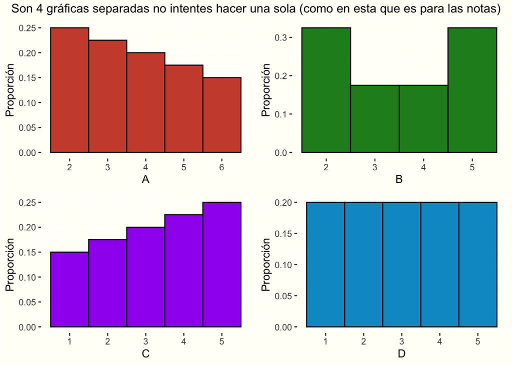

```r
#|echo: false
#SI no lo haces así imprime a lo tonto
ggdraw(arrangeGrob(plotA, plotB, plotC, plotD,
                   top = "Son 4 gráficas separadas no intentes hacer una sola (como en esta que es para las notas)")) +
  theme(plot.background =
          element_rect(fill="#fffff8", color = NA))
```

¿Podemos concluir la forma de la distribución a partir del histograma? Es decir ¿hay distribuciones sesgadas a la izquierda, a la derecha, uniformes, centradas o con colas pesadas?

Realiza el mismo histograma pero ahora con un ancho de banda de `0.25` ¿por qué hubo cambios? Analiza la base de datos (los valores en función de la columna `A`) y concluye.

## 2 Unión de gráficos con `cowplot`

Muchas veces interesa tener una gráfica que conjunte dos imágenes distintas. Por ejemplo la siguiente imagen muestra dos histogramas lado a lado en una sola gráfica.

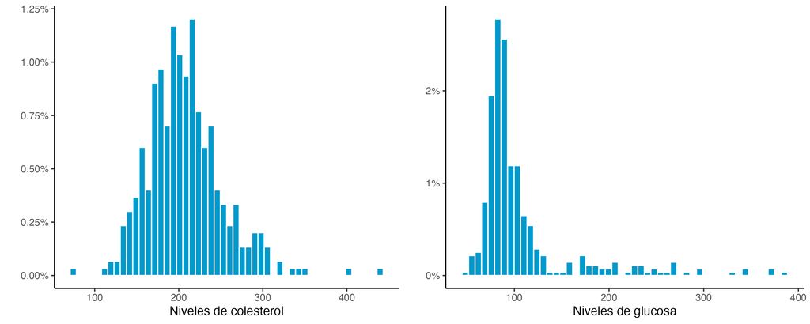

Dos gráficas en una sola

Para poder juntarlos es necesario: 1) hacer cada histograma por separado y 2) usar el paquete `cowplot` para juntarlos.

Empecemos elaborando el primer histograma:

```r
histograma_1 <- ggplot(datos_diabetes) +
  geom_histogram(aes(x = chol, y = ..density..),
                 bins = 50, color = "white", fill = "deepskyblue3") +
  labs(
    y = "",
    x = "Niveles de colesterol"
  ) +
  scale_y_continuous(labels = scales::percent) +
  theme_classic()
```

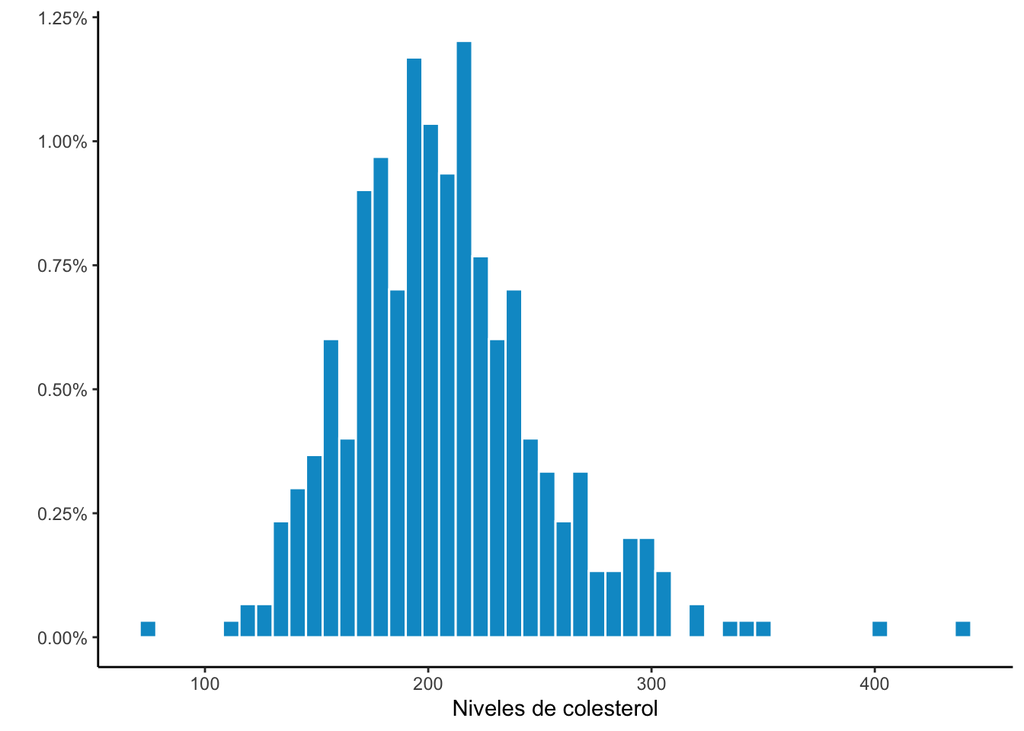

continuemos con el segundo:

```r
histograma_2 <- ggplot(datos_diabetes) +
  geom_histogram(aes(x = stab.glu, y = ..density..),
                 bins = 50, color = "white", fill = "deepskyblue3") +
  labs(
    y = "",
    x = "Niveles de glucosa"
  ) +
  scale_y_continuous(labels = scales::percent) +
  theme_classic()
```

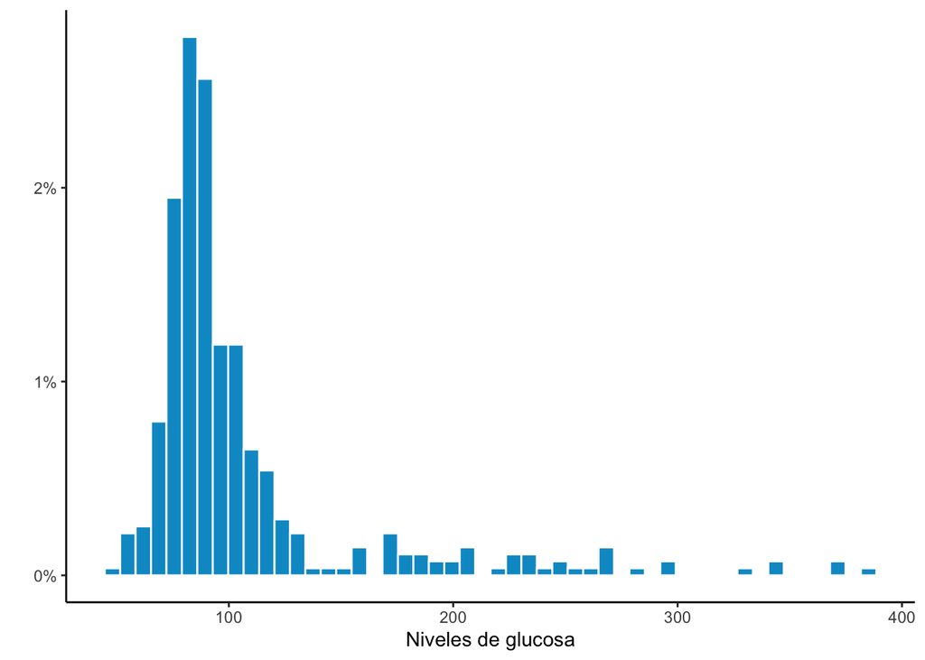

Finalmente con `plot_grid` dentro de `cowplot` las juntamos:

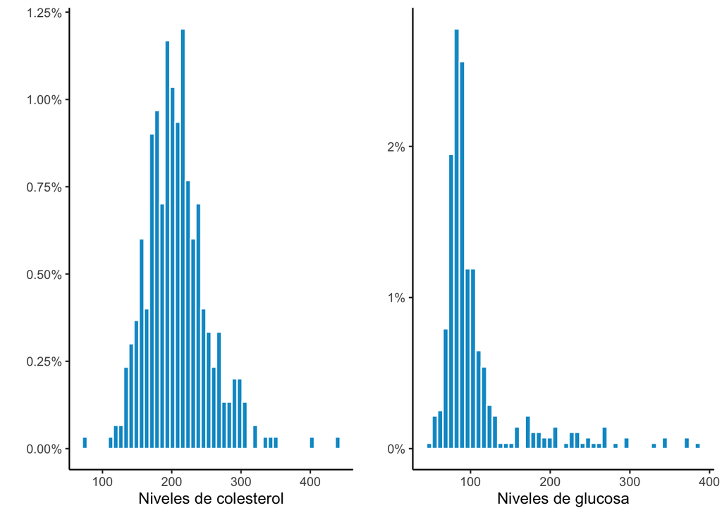

```r
library(cowplot) #para usar plot_grid
plot_grid(histograma_1, histograma_2, ncol = 2) #ncol indica cuántas columnas
```

El paquete `cowplot` permite incluso combinar más de dos gráficos y establecer las alturas.

### 2.1 Ejercicio

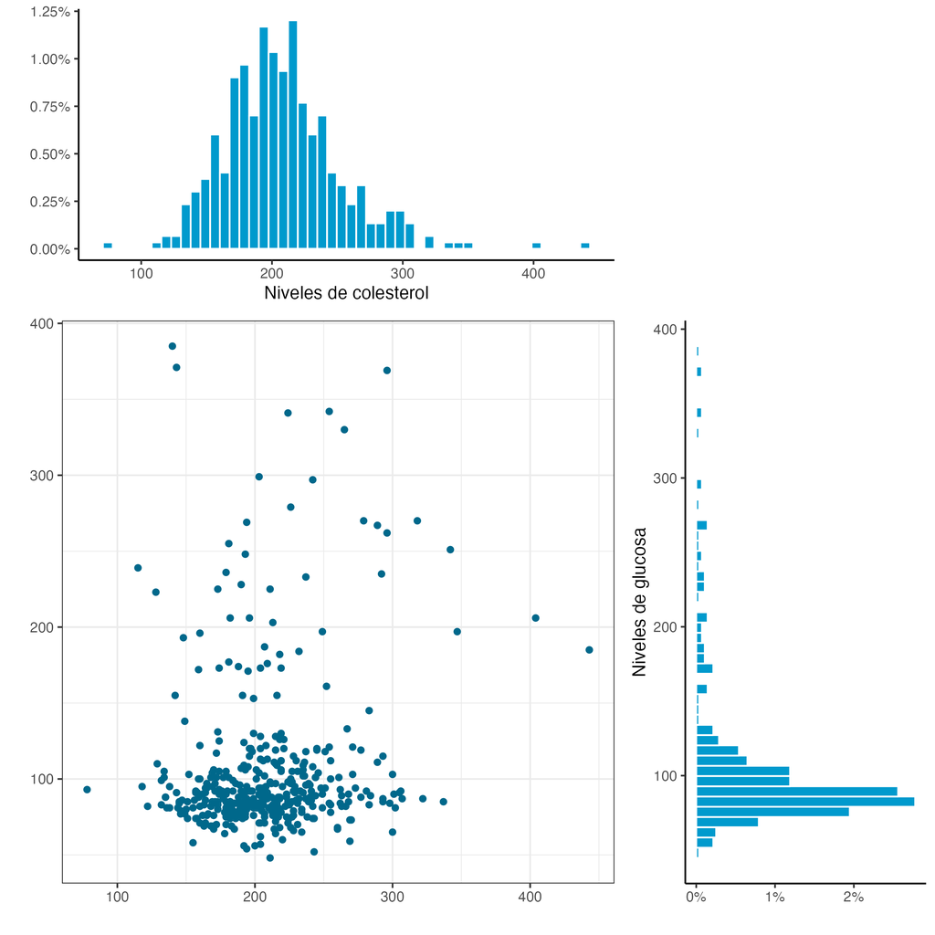

Ejemplo avanzado de combinación de gráficos

Por ejemplo para armar el siguiente gráfico se utilizaron `histograma_1`, `histograma_2` y una tercera gráfica de `colesterol` contra `glucosa` como sigue:

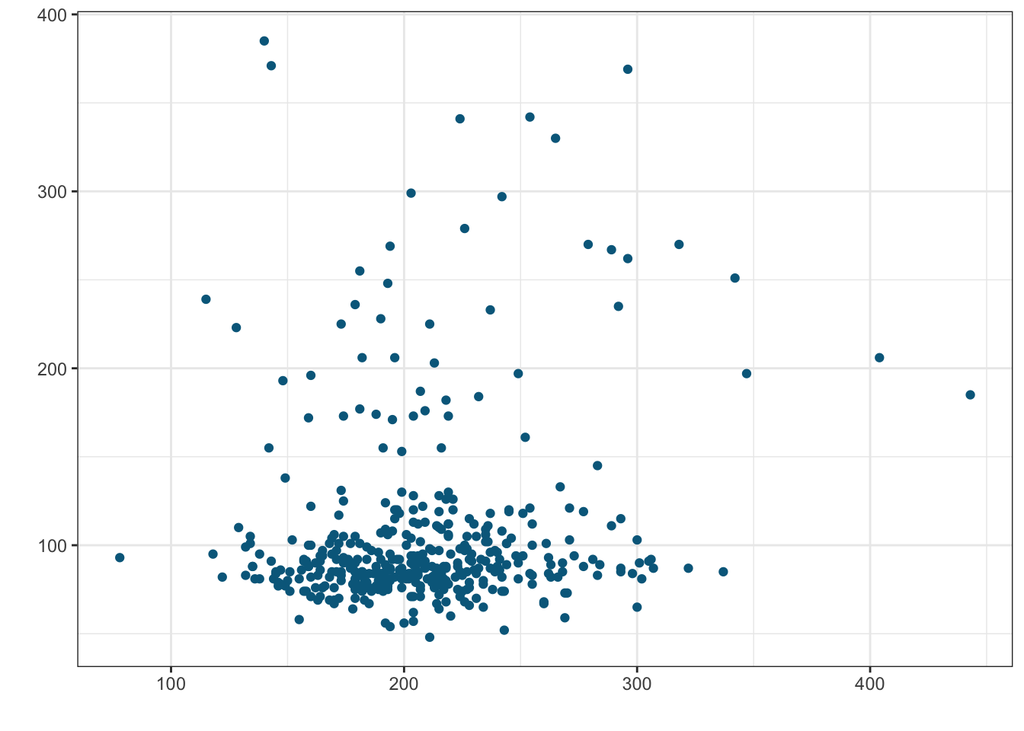

La gráfica de colesterol contra glucosa se almacenó en la variable `col_glu` la cual luego se utilizó en el `plot_grid` como sigue:

```r
plot_grid(histograma_1,            #Primer histograma
          ggplot() + theme_void(), #Genera un cuadro vacío
          col_glu,                 #Gráfica de glucosa vs colesterol
          histograma_2 + coord_flip(), #coord_flip voltea el histograma
          ncol = 2,                #dos columnas
          rel_widths  = c(1, 0.5), #Establece el ancho relativo
          rel_heights = c(0.5, 1)) #Establece la altura relativa
```

Reproduce la gráfica del ejemplo.

**Tip**

Más información de `cowplot` la puedes encontrar [en sus tutoriales](https://wilkelab.org/cowplot/articles/plot_grid.html)

## 3 Para saber más

El [libro de `ggplot2`](https://ggplot2-book.org/) es una excelente referencia para la parte de graficación así como [las notas en español de `rafalab`](https://rafalab.github.io/dslibro/ggplot2.html). Por otro lado el libro de [Fundamentals of Data Visualization](https://clauswilke.com/dataviz/) analiza más a fondo cómo presentar datos de formas que convenzan al público. Para armar historias a partir de los datos ve el libro de [Story-telling with data](https://www.storytellingwithdata.com/books)